# cleaning

## 1) Importing libraries

```python
import polars as pl

from sklearn.preprocessing import OneHotEncoder, StandardScaler

from sklearn.compose import ColumnTransformer
from sklearn.decomposition import PCA

import matplotlib.pyplot as plt
import seaborn as sns

from functions import plots
from pathlib import Path

import joblib
```

## 2) Reading dataset

```python
random_state = 1
primary_color = "#1c3148"
secondary_color = "#c56715"
```

### 2.1) Importing data

Here are the column target descriptions:

| COLUMN | DESCRIPTION |
| --- | --- |
| **age** | The age of the patient. |
| **gender** | Biological sex of the patient (Male/Female). |
| **polyuria** | Whether the patient experienced excessive or frequent urination. |
| **polydipsia** | Whether the patient experienced excessive thirst or extreme fluid intake. |
| **sudden_weight_loss** | Occurrence of a rapid and unexpected decrease in body weight. |
| **weakness** | General feeling of fatigue or lack of physical strength. |
| **polyphagia** | Occurrence of extreme, insatiable hunger. |
| **genital_thrush** | Presence of a yeast infection (Candidiasis) in the genital area. |
| **visual_blurring** | Episodes of blurred or distorted vision. |
| **itching** | General skin irritation or itchy sensations. |
| **irritability** | Heightened emotional sensitivity or agitation. |
| **delayed_healing** | Noticeable slowness in the recovery of wounds or cuts. |
| **partial_paresis** | Weakening or partial loss of voluntary movement in a muscle group. |
| **muscle_stiffness** | Episodes of muscle rigidity or difficulty in movement. |
| **alopecia** | Sudden or patchy hair loss. |
| **obesity** | Classification of being obese based on Body Mass Index (BMI). |
| **class** | Target variable: Diagnosis/Presence of Diabetes. |

```python
dataset = pl.read_csv(
    source = "./data/diabetes_data.csv",
    separator = ";"
)

print(dataset.shape)
dataset.head(2)
```

```
(520, 17)
```

shape: (2, 17)

| age i64 | gender str | polyuria i64 | polydipsia i64 | sudden_weight_loss i64 | weakness i64 | polyphagia i64 | genital_thrush i64 | visual_blurring i64 | itching i64 | irritability i64 | delayed_healing i64 | partial_paresis i64 | muscle_stiffness i64 | alopecia i64 | obesity i64 | class i64 |
| --- | --- | --- | --- | --- | --- | --- | --- | --- | --- | --- | --- | --- | --- | --- | --- | --- |
| 40 | "Male" | 0 | 1 | 0 | 1 | 0 | 0 | 0 | 1 | 0 | 1 | 0 | 1 | 1 | 1 | 1 |
| 58 | "Male" | 0 | 0 | 0 | 1 | 0 | 0 | 1 | 0 | 0 | 0 | 1 | 0 | 1 | 0 | 1 |

### 2.2) Data overview

#### 2.2.1) Overall

We can see bellow, almost all columns works just like boolean values, only few features have number or string value in it.

```python
dataset.describe()
```

shape: (9, 18)

| statistic str | age f64 | gender str | polyuria f64 | polydipsia f64 | sudden_weight_loss f64 | weakness f64 | polyphagia f64 | genital_thrush f64 | visual_blurring f64 | itching f64 | irritability f64 | delayed_healing f64 | partial_paresis f64 | muscle_stiffness f64 | alopecia f64 | obesity f64 | class f64 |
| --- | --- | --- | --- | --- | --- | --- | --- | --- | --- | --- | --- | --- | --- | --- | --- | --- | --- |
| "count" | 520.0 | "520" | 520.0 | 520.0 | 520.0 | 520.0 | 520.0 | 520.0 | 520.0 | 520.0 | 520.0 | 520.0 | 520.0 | 520.0 | 520.0 | 520.0 | 520.0 |
| "null_count" | 0.0 | "0" | 0.0 | 0.0 | 0.0 | 0.0 | 0.0 | 0.0 | 0.0 | 0.0 | 0.0 | 0.0 | 0.0 | 0.0 | 0.0 | 0.0 | 0.0 |
| "mean" | 48.028846 | null | 0.496154 | 0.448077 | 0.417308 | 0.586538 | 0.455769 | 0.223077 | 0.448077 | 0.486538 | 0.242308 | 0.459615 | 0.430769 | 0.375 | 0.344231 | 0.169231 | 0.615385 |
| "std" | 12.151466 | null | 0.500467 | 0.497776 | 0.493589 | 0.492928 | 0.498519 | 0.41671 | 0.497776 | 0.5003 | 0.428892 | 0.498846 | 0.495661 | 0.484589 | 0.475574 | 0.375317 | 0.486973 |
| "min" | 16.0 | "Female" | 0.0 | 0.0 | 0.0 | 0.0 | 0.0 | 0.0 | 0.0 | 0.0 | 0.0 | 0.0 | 0.0 | 0.0 | 0.0 | 0.0 | 0.0 |
| "25%" | 39.0 | null | 0.0 | 0.0 | 0.0 | 0.0 | 0.0 | 0.0 | 0.0 | 0.0 | 0.0 | 0.0 | 0.0 | 0.0 | 0.0 | 0.0 | 0.0 |
| "50%" | 48.0 | null | 0.0 | 0.0 | 0.0 | 1.0 | 0.0 | 0.0 | 0.0 | 0.0 | 0.0 | 0.0 | 0.0 | 0.0 | 0.0 | 0.0 | 1.0 |
| "75%" | 57.0 | null | 1.0 | 1.0 | 1.0 | 1.0 | 1.0 | 0.0 | 1.0 | 1.0 | 0.0 | 1.0 | 1.0 | 1.0 | 1.0 | 0.0 | 1.0 |
| "max" | 90.0 | "Male" | 1.0 | 1.0 | 1.0 | 1.0 | 1.0 | 1.0 | 1.0 | 1.0 | 1.0 | 1.0 | 1.0 | 1.0 | 1.0 | 1.0 | 1.0 |

#### 2.2.2) Correcting `dtypes`

Setting the correct `dtypes` for each column not only help us to understand more the data, but also help us to set new features properly. As bonus, our dataset size can also decrease, since we are reducing some predefined and unnecessary space for it.

```python
boolean_columns = ['polyuria', 'polydipsia', 'sudden_weight_loss', 'weakness', 'polyphagia', 'genital_thrush', 'visual_blurring', 'itching', 'irritability', 'delayed_healing', 'partial_paresis', 'muscle_stiffness', 'alopecia', 'obesity', 'class']

dataset = dataset.with_columns(
    [
        pl.col(column).cast(pl.Boolean) for column in boolean_columns
    ]
)

dataset = dataset.with_columns(
    pl.col("gender").cast(pl.Enum(categories = ["Male", "Female"])),
    pl.col("age").cast(pl.Int8)
)

print(f"Dataset new size: {dataset.estimated_size(unit = 'bytes')} bytes")
print(dataset.shape)
dataset.head(2)
```

```
Dataset new size: 2030 bytes
(520, 17)
```

shape: (2, 17)

| age i8 | gender enum | polyuria bool | polydipsia bool | sudden_weight_loss bool | weakness bool | polyphagia bool | genital_thrush bool | visual_blurring bool | itching bool | irritability bool | delayed_healing bool | partial_paresis bool | muscle_stiffness bool | alopecia bool | obesity bool | class bool |
| --- | --- | --- | --- | --- | --- | --- | --- | --- | --- | --- | --- | --- | --- | --- | --- | --- |
| 40 | "Male" | false | true | false | true | false | false | false | true | false | true | false | true | true | true | true |
| 58 | "Male" | false | false | false | true | false | false | true | false | false | false | true | false | true | false | true |

### 2.3) Plots

#### 2.3.1) Numerical

Luckily for us, `age` follows a normal distribution.

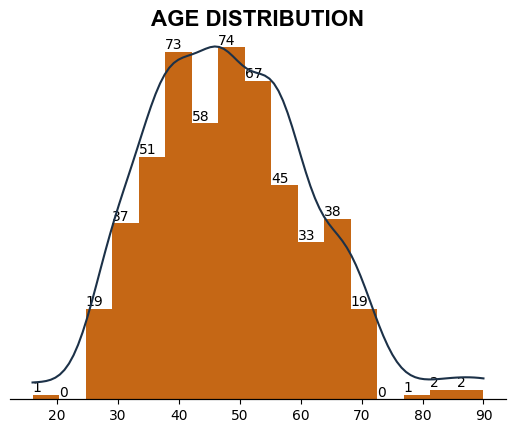

```python
fig, ax = plt.subplots()


plots.plot_histogram(
    ax = ax,
    values = dataset["age"],
    title = {
        "text" : "AGE DISTRIBUTION",
        "size": 16
    },
    color = secondary_color,
    labels = "age",
    tooltip = {
        "horizontalalignment": "left",
        "verticalalignment": "bottom",
    },
    kde = {
        "color": primary_color
    }
)

plt.show()
```

#### 2.3.2) Categorical

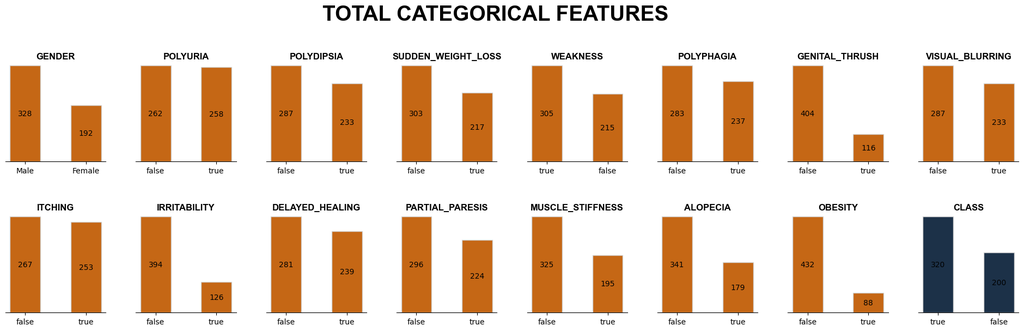

```python
columns = [ 'gender', 'polyuria', 'polydipsia', 'sudden_weight_loss', 'weakness', 'polyphagia', 'genital_thrush', 'visual_blurring', 'itching', 'irritability', 'delayed_healing', 'partial_paresis', 'muscle_stiffness', 'alopecia', 'obesity', 'class']
colors = [secondary_color]*15 + [primary_color]

fig, axs = plt.subplots(
    nrows = 2,
    ncols = 8,
    figsize = (24, 6),
    gridspec_kw = {
        "hspace": .5,
        "wspace": .3
    }
)

axs = axs.flatten()

for index, column in enumerate(columns):

    plot_df = dataset.group_by(
        column
    ).agg(
        pl.col(column).len().alias("TOTAL")
    ).with_columns(
        pl.col(column).cast(pl.String)
    ).sort(
        by = "TOTAL",
        descending = True
    )

    plots.plot_bar(
        ax = axs[index],
        x_values = plot_df[column],
        y_values = plot_df["TOTAL"],
        title = {
            "text": f"{column}".upper()
        },
        x_label = {
            "text": "",
        },

        y_label=  {
            "text": ""
        },
        colors = colors[index],
        legends = column
    )

plt.suptitle(
    t = "TOTAL CATEGORICAL FEATURES",
    fontsize = "28",
    y = 1.05,
    fontweight = "bold",
    fontfamily = "arial"
)
plt.show()
```

#### 2.3.3) Correlation

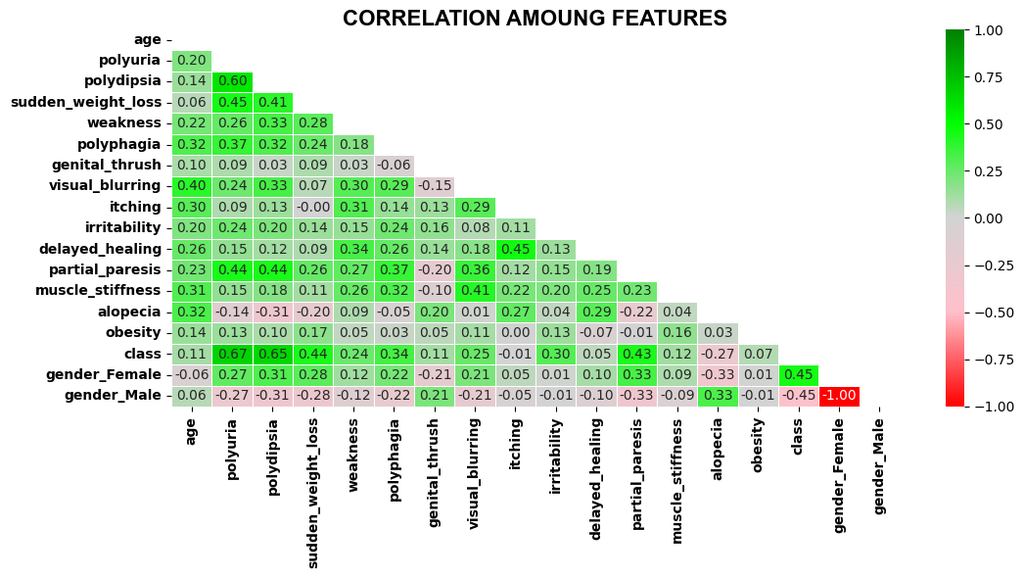

```python
fig, ax = plt.subplots(
    figsize = (12, 5)
)

plots.plot_heatmap(
    ax = ax,
    corr_dataset = pl.concat(
    items = [dataset.drop("gender"),
    dataset["gender"].to_dummies() ],
    how = "horizontal"
).corr(),
    title = {
        "text": "CORRELATION AMOUNG FEATURES",
        "size": 16,
    },
    hayticks = "right",
    xticksrotation = 90,
    vmax = 1,
    vmin = -1
)

plt.show()
```

As we can saw on top, we see two major and one minor problems:

- **Major problems**:
  1. The first one is that `polyuria` and `polydipsia` have high correlation between themselves. That is because people that have high tendencies to drink lots of water also have needs to go to the bathroom, which makes work with thoses features features separately impossible. Therefore, we are going to apply PCA in order to unite these parameters.
  2. Also, we see that this dataset have unfortunately interview to many woman with diabetes. Looking into the graph, we can conclude that almost all of them have the disease, which is bad for the model to understand. Since we know that gender for its own do not affect diabetes chances, we decided to drop this column.
- **Minor**:
  1. If we are trying to create a machine learning model that could be used later, it is also better to drop `irritability` column, since it can be misunderstood very easy - giving to the user a different output depending of the day.

## 3) Preparing data

### 3.1) Preprocessing

Here, we are going to create preprocessing `ColumnTransformer` variable called `pre_processing` that it is responsible to handle all sort of transformations with our dataset:

- **pca**: responsible to reunite and treated `polyuria` and `polydipsia` as one single feature, given its high correlation between themselves and target `class`;
- **standard_scaler**: good to uniform standard deviation of `age` in order to match the same ranges of categorical columns;

```python
dataset = dataset.drop(["gender", "irritability"])

pca = PCA(n_components = 1)
one_hot_encoder = OneHotEncoder()
standard_scaler = StandardScaler()

pre_processing = ColumnTransformer(
    transformers = [
        ("pca", pca, ["polyuria", "polydipsia"]),
        ("age_encoder", standard_scaler, ["age"]),
    ],
    remainder = 'passthrough'
)

pre_processing
```

```
ColumnTransformer(remainder='passthrough',
                  transformers=[('pca', PCA(n_components=1),
                                 ['polyuria', 'polydipsia']),
                                ('age_encoder', StandardScaler(), ['age'])])
```

### 3.2) Saving `ColumnTransformer`

Here, we are saving transformations in order to use it later in production.

```python
joblib.dump(
    value = pre_processing,
    filename = "./models/preprocessing/pre_processing.joblib"
)
```

```
['./models/preprocessing/pre_processing.joblib']
```

### 3.3) Saving cleaned dataset

Saving cleaned dataset to use it later to test models.

```python
dataset.write_parquet(
    file = "./dataset/cleaned_dataset.parquet"
)
```